# USDA Nutritional Data Analysis

## Created by Christopher Wong: 8-4-22

### Last updated: 1-19-25

#### Data Preprocessing

Read and merged the datasets on a common key, handled missing values, converted non-numeric data into numeric formats, created a cleaned dataset for analysis.

```r
# Read the data files into data frames
macroNut <- read.csv("./USDA_Macronutrients.csv", header = TRUE)
microNut <- read.csv("./USDA_Micronutrients.csv", header = TRUE)

# Merge the data frames using the variable "ID"
USDA <- merge(macroNut, microNut, by = "ID")

# Checking the data types
str(USDA)
```

```
## 'data.frame':    7057 obs. of  15 variables:
##  $ ID          : int  1001 1002 1003 1004 1005 1006 1007 1008 1009 1010 ...
##  $ Description : chr  "BUTTER,WITH SALT" "BUTTER,WHIPPED,WITH SALT" "BUTTER OIL,ANHYDROUS" "CHEESE,BLUE" ...
##  $ Calories    : int  717 717 876 353 371 334 300 376 403 387 ...
##  $ Protein     : num  0.85 0.85 0.28 21.4 23.24 ...
##  $ TotalFat    : num  81.1 81.1 99.5 28.7 29.7 ...
##  $ Carbohydrate: num  0.06 0.06 0 2.34 2.79 0.45 0.46 3.06 1.28 4.78 ...
##  $ Sodium      : chr  "714" "827" "2" "1,395" ...
##  $ Cholesterol : int  215 219 256 75 94 100 72 93 105 103 ...
##  $ Sugar       : num  0.06 0.06 0 0.5 0.51 0.45 0.46 NA 0.52 NA ...
##  $ Calcium     : int  24 24 4 528 674 184 388 673 721 643 ...
##  $ Iron        : num  0.02 0.16 0 0.31 0.43 0.5 0.33 0.64 0.68 0.21 ...
##  $ Potassium   : chr  "24" "26" "5" "256" ...
##  $ VitaminC    : num  0 0 0 0 0 0 0 0 0 0 ...
##  $ VitaminE    : num  2.32 2.32 2.8 0.25 0.26 0.24 0.21 NA 0.29 NA ...
##  $ VitaminD    : num  1.5 1.5 1.8 0.5 0.5 0.5 0.4 NA 0.6 NA ...
```

```r
# Delete commas from the sodium recs, then make data types numeric instead
USDA$Sodium <- gsub(",", "", USDA$Sodium)
USDA$Sodium <- as.numeric(USDA$Sodium)

# Delete commas from the potassium recs, then make data types numeric instead
USDA$Potassium <- gsub(",", "", USDA$Potassium)
USDA$Potassium <- as.numeric(USDA$Potassium)

# Remove records (rows) with missing values in more than 6 attributes (columns)
# get the rows with 4 or less missing values
USDA <- USDA[rowSums(is.na(USDA)) <= 4, ]

# Checking the data types to see # of records remaining in the data frame
str(USDA)
```

```
## 'data.frame':    6887 obs. of  15 variables:
##  $ ID          : int  1001 1002 1003 1004 1005 1006 1007 1008 1009 1010 ...
##  $ Description : chr  "BUTTER,WITH SALT" "BUTTER,WHIPPED,WITH SALT" "BUTTER OIL,ANHYDROUS" "CHEESE,BLUE" ...
##  $ Calories    : int  717 717 876 353 371 334 300 376 403 387 ...
##  $ Protein     : num  0.85 0.85 0.28 21.4 23.24 ...
##  $ TotalFat    : num  81.1 81.1 99.5 28.7 29.7 ...
##  $ Carbohydrate: num  0.06 0.06 0 2.34 2.79 0.45 0.46 3.06 1.28 4.78 ...
##  $ Sodium      : num  714 827 2 1395 560 ...
##  $ Cholesterol : int  215 219 256 75 94 100 72 93 105 103 ...
##  $ Sugar       : num  0.06 0.06 0 0.5 0.51 0.45 0.46 NA 0.52 NA ...
##  $ Calcium     : int  24 24 4 528 674 184 388 673 721 643 ...
##  $ Iron        : num  0.02 0.16 0 0.31 0.43 0.5 0.33 0.64 0.68 0.21 ...
##  $ Potassium   : num  24 26 5 256 136 152 187 93 98 95 ...
##  $ VitaminC    : num  0 0 0 0 0 0 0 0 0 0 ...
##  $ VitaminE    : num  2.32 2.32 2.8 0.25 0.26 0.24 0.21 NA 0.29 NA ...
##  $ VitaminD    : num  1.5 1.5 1.8 0.5 0.5 0.5 0.4 NA 0.6 NA ...
```

```r
# Replace missing values for Sugar, Vitamin E and Vitamin D, with the mean value for the respective variable
USDA$Sugar[is.na(USDA$Sugar)]       <- mean(USDA$Sugar[!is.na(USDA$Sugar)])
USDA$VitaminE[is.na(USDA$VitaminE)] <- mean(USDA$VitaminE[!is.na(USDA$VitaminE)])
USDA$VitaminD[is.na(USDA$VitaminD)] <- mean(USDA$VitaminD[!is.na(USDA$VitaminD)])

#remove all remaining records with missing values, save to new data frame
USDAclean <- USDA[complete.cases(USDA), ]

# Checking the data types to see # of records remaining in the data frame
str(USDAclean)
```

```
## 'data.frame':    6310 obs. of  15 variables:
##  $ ID          : int  1001 1002 1003 1004 1005 1006 1007 1008 1009 1010 ...
##  $ Description : chr  "BUTTER,WITH SALT" "BUTTER,WHIPPED,WITH SALT" "BUTTER OIL,ANHYDROUS" "CHEESE,BLUE" ...
##  $ Calories    : int  717 717 876 353 371 334 300 376 403 387 ...
##  $ Protein     : num  0.85 0.85 0.28 21.4 23.24 ...
##  $ TotalFat    : num  81.1 81.1 99.5 28.7 29.7 ...
##  $ Carbohydrate: num  0.06 0.06 0 2.34 2.79 0.45 0.46 3.06 1.28 4.78 ...
##  $ Sodium      : num  714 827 2 1395 560 ...
##  $ Cholesterol : int  215 219 256 75 94 100 72 93 105 103 ...
##  $ Sugar       : num  0.06 0.06 0 0.5 0.51 ...
##  $ Calcium     : int  24 24 4 528 674 184 388 673 721 643 ...
##  $ Iron        : num  0.02 0.16 0 0.31 0.43 0.5 0.33 0.64 0.68 0.21 ...
##  $ Potassium   : num  24 26 5 256 136 152 187 93 98 95 ...
##  $ VitaminC    : num  0 0 0 0 0 0 0 0 0 0 ...
##  $ VitaminE    : num  2.32 2.32 2.8 0.25 0.26 ...
##  $ VitaminD    : num  1.5 1.5 1.8 0.5 0.5 ...
```

#### Sodium Content Analysis

Consuming foods with such high sodium levels can lead to health issues such as hypertension, heart disease, and stroke. It is important to monitor and limit the intake of these foods, especially for individuals with health conditions that require low sodium diets. Below is a list of the top 20 foods and ingredients with the highest sodium levels.

```r
# Sort the data frame by Sodium in descending order and select the top 20 rows
top20_sodium <- USDAclean[order(-USDAclean$Sodium), ][1:20, ]

# Display the top 20 foods/ingredients with the highest sodium levels
top20_sodium
```

```
##         ID                                             Description Calories
## 265   2047                                              SALT,TABLE        0
## 5324 18372                            LEAVENING AGENTS,BAKING SODA        0
## 5698 19225                         DESSERTS,RENNIN,TABLETS,UNSWTND       84
## 922   6075                       SOUP,BF BROTH OR BOUILLON,PDR,DRY      213
## 923   6076                               SOUP,BEEF BROTH,CUBED,DRY      170
## 926   6081                              SOUP,CHICK BROTH CUBES,DRY      198
## 925   6080                        SOUP,CHICK BROTH OR BOUILLON,DRY      267
## 1303  6979                                            ADOBO FRESCO      271
## 938   6115                                        GRAVY,AU JUS,DRY      313
## 5321 18369 LEAVENING AGENTS,BAKING PDR,DOUBLE-ACTING,NA AL SULFATE       53
## 7024 43497                                  JELLYFISH,DRIED,SALTED       36
## 924   6077                                  SOUP,BF NOODLE,DRY,MIX      324
## 930   6094                                      SOUP,ONION,DRY,MIX      293
## 5322 18370  LEAVENING AGENTS,BAKING PDR,DOUBLE-ACTING,STRAIGHT PO4       51
```

[output cut: 48 more lines]

#### Vitamin C distribution in foods.

Vitamin C is an essential nutrient that plays a key role in maintaining overall health and immunity. Below are histograms showing the distribution of Vitamin C content in foods. We see that the vast majority of foods have low to moderate levels of Vitamin C. For a more detailed view, we also created a histogram for foods with Vitamin C levels of 100 or more.

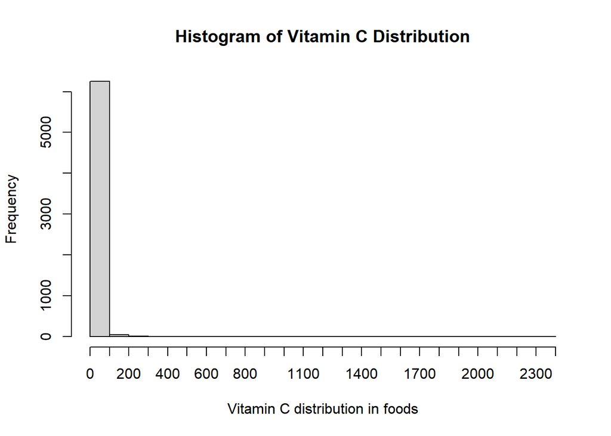

```r
# Histogram for Vitamin C distribution for all foods
hist(USDAclean$VitaminC,
     breaks = seq(0, max(USDAclean$VitaminC, na.rm = TRUE), by = 100),
     xlab = "Vitamin C distribution in foods",
     main = "Histogram of Vitamin C Distribution",
     xlim = c(0, max(USDAclean$VitaminC, na.rm = TRUE)),
     xaxt = "n")  # Suppress the default x-axis
axis(1, at = seq(0, max(USDAclean$VitaminC, na.rm = TRUE), by = 100))
```

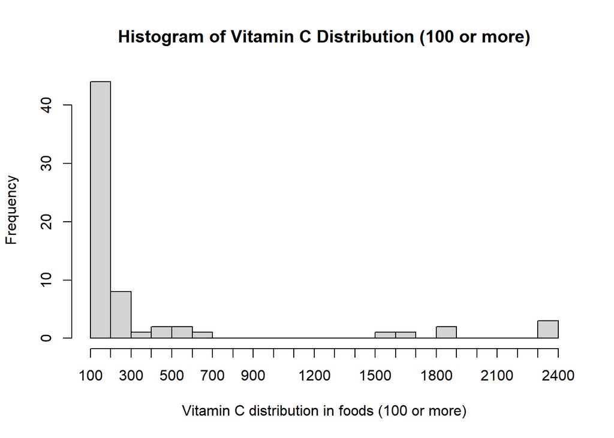

```r
# Filter the data to include only foods with Vitamin C levels of 100 or more
high_vitaminC <- USDAclean[USDAclean$VitaminC >= 100, ]
# Histogram for Vitamin C distribution for foods with Vitamin C levels of 100 or more
hist(high_vitaminC$VitaminC,
     breaks = seq(100, max(high_vitaminC$VitaminC, na.rm = TRUE), by = 100),
     xlab = "Vitamin C distribution in foods (100 or more)",
     main = "Histogram of Vitamin C Distribution (100 or more)",
     xlim = c(100, max(high_vitaminC$VitaminC, na.rm = TRUE)),
     xaxt = "n")  # Suppress the default x-axis

# Customize the x-axis to reflect breaks of 100
axis(1, at = seq(100, max(high_vitaminC$VitaminC, na.rm = TRUE), by = 100))
```

#### Distribution of values for TotalFat, Protein and Carbohydrate.

The boxplot below visualizes the distribution of Total Fat, Protein, and Carbohydrates in the dataset. This visualization aids in comparing the central tendencies and variability of these macronutrients, identifying outliers, and gaining insights into the nutritional composition of the foods in the dataset.

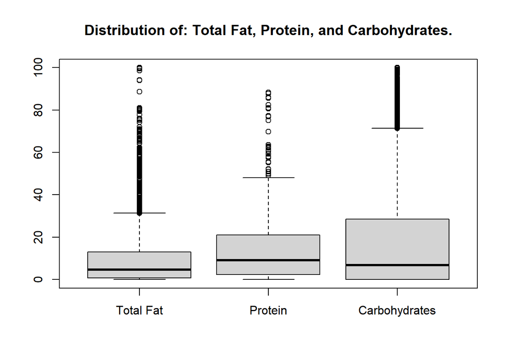

```r
boxplot(USDAclean$TotalFat, USDAclean$Protein, USDAclean$Carbohydrate,
        main  = "Distribution of: Total Fat, Protein, and Carbohydrates.",
        names = c("Total Fat", "Protein", "Carbohydrates"))
```

#### Relationship between a food’s TotalFat content and its Calorie content.

The graph below indicates that there is a positive relationship between Total Fat content and Calorie content in foods. This means that foods with higher fat content tend to have higher calorie content. This relationship is expected because fat is a dense source of energy, providing 9 calories per gram, compared to 4 calories per gram for protein and carbohydrates. Therefore, as the fat content in foods increases, the overall calorie content also increases.

Understanding this relationship is important for nutritional analysis and dietary planning, as it helps in assessing the energy contribution of fat in different foods.

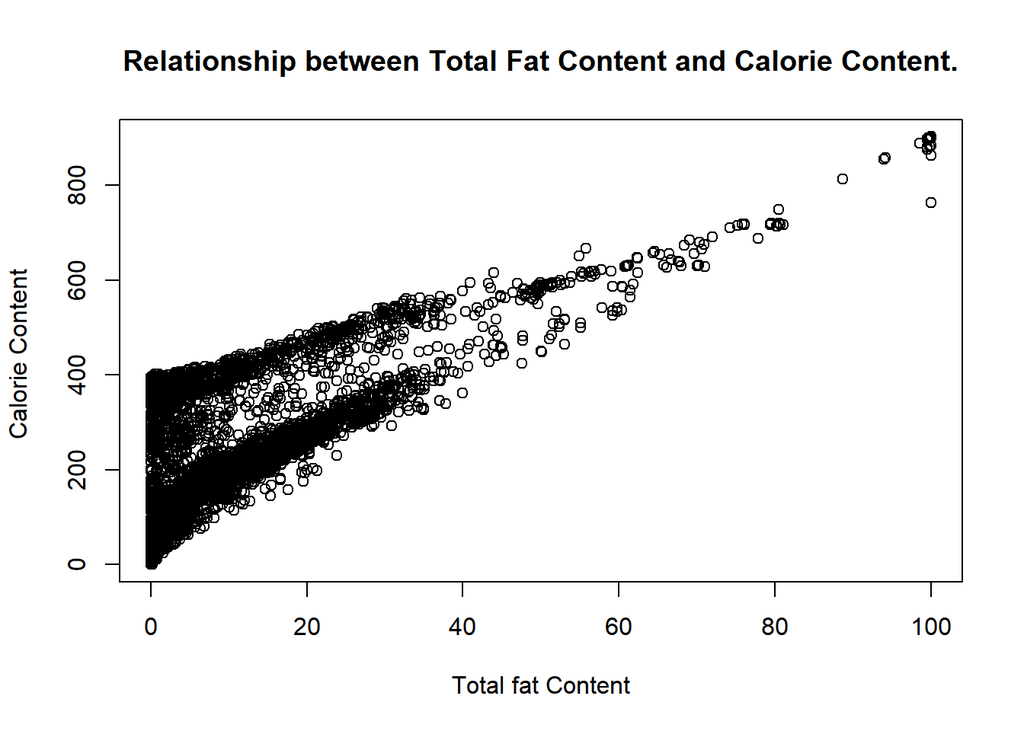

```r
plot(USDAclean$TotalFat, USDAclean$Calories,
     main = "Relationship between Total Fat Content and Calorie Content.",
     xlab = "Total fat Content",
     ylab = "Calorie Content ")
```

#### Adding high nutrient indicators and counting foods with high sodium and fat

By adding binary indicators, we provide a clear way to identify and categorize foods based on their nutrient levels. This can be useful for further nutritional analysis and dietary planning.

```r
# Make new columns for: High Sodium, High Calories, High Protein, High Sugar, and High Fat
# Check if value is greater than the avg. if true: set it equal to 1
USDAclean$HSodium   <- 0
USDAclean$HSodium[USDAclean$Sodium     > mean(USDAclean$Sodium)]   <- 1

USDAclean$HCalories <- 0
USDAclean$HCalories[USDAclean$Calories > mean(USDAclean$Calories)] <- 1

USDAclean$HProtein  <- 0
USDAclean$HProtein[USDAclean$Protein   > mean(USDAclean$Protein)]  <- 1

USDAclean$HSugar    <- 0
USDAclean$HSugar[USDAclean$Sodium      > mean(USDAclean$Sodium)]   <- 1

USDAclean$HFat      <- 0
USDAclean$HFat[USDAclean$Sodium        > mean(USDAclean$Sodium)]   <- 1

# Number of foods have both high sodium and high fat
sum(apply(USDAclean[c("HSodium", "HFat")], 1, function(x) all(x == 1)))
```

```
## [1] 1827
```

```r
# 1827 foods have both high sodium and high fat
```

#### Average amount of iron for high and low protein foods.

Iron is an essential nutrient that plays a crucial role in oxygen transport and energy production. Understanding the relationship between protein and iron content in foods can help in creating balanced diets that support overall health and well-being.

Findings: - Low Protein Foods: The average amount of iron is approximately 2.70 mg. - High Protein Foods: The average amount of iron is approximately 3.07 mg.

High protein foods tend to have a slightly higher average iron content compared to low protein foods. This information is important for nutritional analysis and dietary planning, helping to ensure adequate intake of both protein and iron.

```r
# average amount of iron, for high and low protein foods
meanIron.lowProtein  <- mean(USDAclean$Iron[USDAclean$HProtein == 0])
meanIron.lowProtein
```

```
## [1] 2.696634
```

```r
meanIron.highProtein <- mean(USDAclean$Iron[USDAclean$HProtein == 1])
meanIron.highProtein
```

```
## [1] 3.069541
```

#### Custom HealthCheck program to detect unhealthy foods.

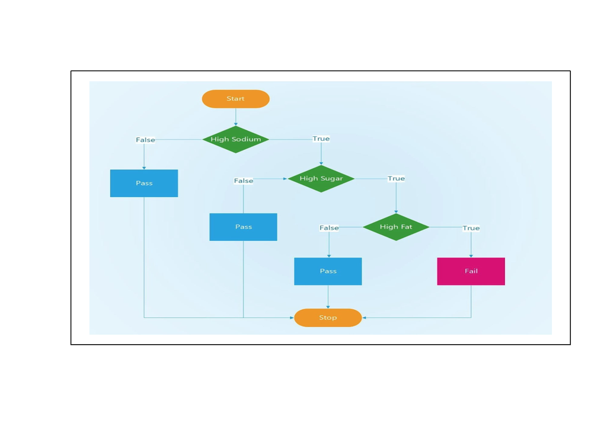

```r
# Used this algorithm chart as a basis for the function
require(jpeg)
file <- readJPEG("HealthCheck.jpg")
plot(1:4, ty = "n", ann = FALSE, xaxt = "n", yaxt = "n")
rasterImage(file, 1, 1, 4, 4)
```

```r
#logic according to flowchart basis
HealthCheck <- function(sodium, sugar, fat) {

  if      (sodium == 0) return("Pass")

  else if (sugar == 0)  return("Pass")
  else if (fat == 0)    return("Pass")

  else                  return("Fail")
}
#input each type of food into the function
USDAclean$HealthCheck <- apply(USDAclean[, c("HSodium", "HSugar", "HFat")], 1,
                function(x) HealthCheck(x["HSodium"], x["HSugar"], x["HFat"]))

#number of failed foods
length(which(USDAclean$HealthCheck == "Fail"))
```

```
## [1] 1827
```

#### Correlation among Calories, Protein, Total Fat, Carbohydrate, Sodium and Cholesterol.

The plot below provides a visual representation of the correlation between Calories, Protein, Total Fat, Carbohydrate, Sodium, and Cholesterol.

- Positive Correlations: Strong positive correlations are indicated by darker colors and larger circles. For example, Calories show a strong positive correlations with Total Fat.
- Negative Correlations: Negative correlations, are indicated by different colors and smaller circles.
- Strength of Relationships: The size and color intensity of the circles indicate the strength of the correlations, with larger and darker circles representing stronger correlations. This visualization helps in understanding how these nutritional components are related to each other, which is useful for nutritional analysis and dietary planning.

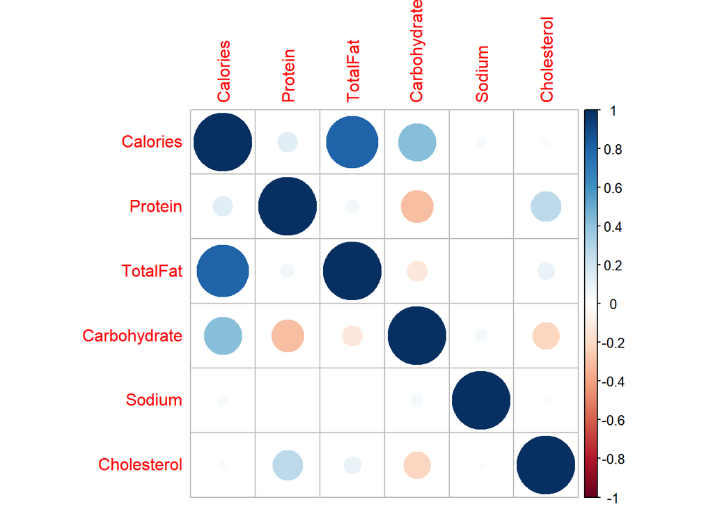

```r
library(corrplot)
#create matrix
nutCorrplot = cor(USDAclean[, c("Calories", "Protein", "TotalFat",
                  "Carbohydrate", "Sodium", "Cholesterol")])

#plotting
corrplot(nutCorrplot)
```

#### Statisical significance of the correlation between Calories and Total Fat.

The correlation between Calories and Total Fat is statistically significant (p-value < 2.2e-16), indicating a strong relationship between these two variables.

```r
# Find the pvalue using the function
cor.test(USDAclean$Calories, USDAclean$TotalFat)
```

```
##
##  Pearson's product-moment correlation
##
## data:  USDAclean$Calories and USDAclean$TotalFat
## t = 107.58, df = 6308, p-value < 2.2e-16
## alternative hypothesis: true correlation is not equal to 0
## 95 percent confidence interval:
##  0.7956139 0.8130305
## sample estimates:
##      cor
## 0.804495
```

```r
# Set alpha = 0.05.
# Now we compare it to the pvalue <  2.2 E-16
# Since the pvalue is less than alpha, the correlation between Calories and Total Fat statistically significant.
```